# Bayesian FE & RE NMA for HR data (via gemtc package) - Result Generation

Sandro Gsteiger, Nick Howlett

2020-06-19

## Introduction

This vignette provides a short example of a Bayesian NMA for HR data. The model fit relies on the `gemtc` package, pre- and post-processing is done with `gemtcPlus`.

## Prepare the environment

```r
knitr::opts_chunk$set(echo = TRUE)

library(dplyr)
library(gemtc)
library(gemtcPlus)
library(ggmcmc)
```

## Load in the data

```r
# load example data
data("hr_data", package = "gemtcPlus")
```

## Plan the model

```r
#Plan model
model_plan <- plan_hr(bth.model = "FE",
                          n.chain = 3,
                          n.iter = 6000,
                          thin = 1,
                          n.adapt = 1000,
                          link = "identity",
                          linearModel = "fixed")
```

## Fit the model

```r
model  <- nma_fit(model_input = model_input)
```

## Post processing

[figure not shown]

```r
ggs_traceplot(ggs(model$samples))
```

[figure not shown]

```r
ggs_density(ggs(model$samples))
```

```r
summary(model)
```

```
##
## Results on the Mean Difference scale
##
## Iterations = 1:6000
## Thinning interval = 1
## Number of chains = 3
## Sample size per chain = 6000
##
## 1. Empirical mean and standard deviation for each variable,
##    plus standard error of the mean:
##
##           Mean      SD  Naive SE Time-series SE
## d.B.A -0.12835 0.05539 0.0004129      0.0004129
## d.C.B  0.19726 0.08320 0.0006201      0.0006313
## d.C.D  0.03578 0.12182 0.0009080      0.0008890
## d.C.E -0.09242 0.06593 0.0004914      0.0004910
## d.D.F  0.20852 0.19508 0.0014540      0.0014541
##
## 2. Quantiles for each variable:
##
##           2.5%      25%      50%      75%    97.5%
## d.B.A -0.23636 -0.16594 -0.12837 -0.09106 -0.01975
## d.C.B  0.03411  0.14194  0.19794  0.25263  0.36011
## d.C.D -0.20209 -0.04794  0.03582  0.11856  0.27699
## d.C.E -0.22187 -0.13704 -0.09198 -0.04728  0.03591
## d.D.F -0.17147  0.07815  0.20894  0.33972  0.59366
##
## -- Model fit (residual deviance):
##
##      Dbar        pD       DIC
##  5.481882  4.980620 10.462501
##
## 7 data points, ratio 0.7831, I^2 = 0%
```

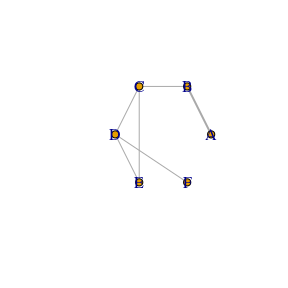

```r
plot(model_input$fitting_data)
```

```r
get_mtc_sum(model)
```

```
##     DIC   pD resDev dataPoints
## 1 10.46 4.98   5.48          7
```

# Random Effects example

Update model plan and re-run fit.

```r
#Plan model
model_plan <- plan_hr(bth.model = "RE",
                      n.chain = 3,
                      n.iter = 6000,
                      thin = 1,
                      n.adapt = 1000,
                      link = "identity",
                      linearModel = "random",
                      bth.prior = mtc.hy.prior(type = "var", distr = "dlnorm",-4.18, 1 / 1.41 ^ 2)
)
```

## Fit the model

```r
model  <- nma_fit(model_input = model_input)
```

# Post processing

## Inspect convergence

The `ggmcmc` package provides ggplot2 versions of all major convergence plots and diagnostics.

**Figure** Traceplot

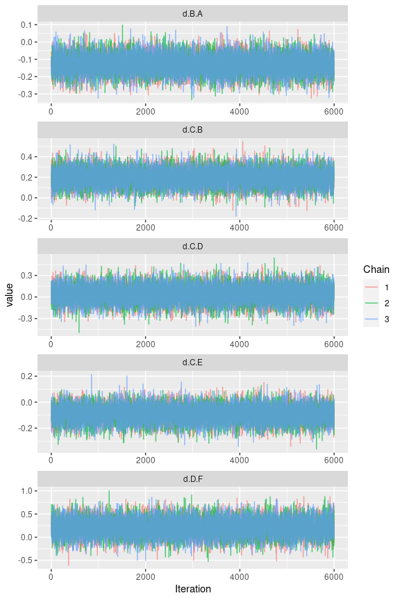

```r
ggs_traceplot(ggs(model$samples))
```

**Figure** Densityplot

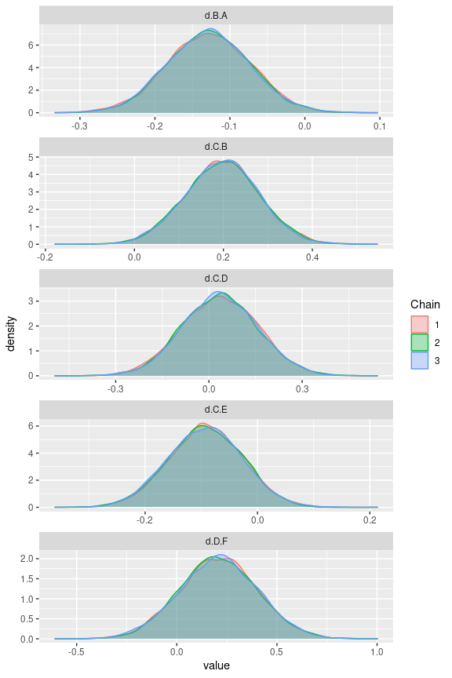

```r
ggs_density(ggs(model$samples))
```

**Figure** Brooks-Gelman-Rubin convergence diagnostic (Rhat)

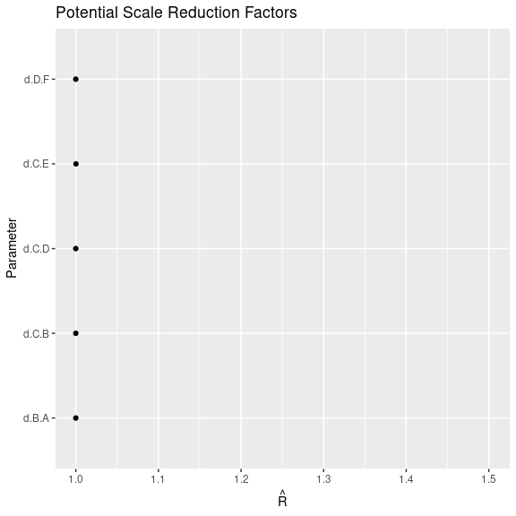

```r
ggs_Rhat(ggs(model$samples))
```

**Figure** Auto-correlation plot

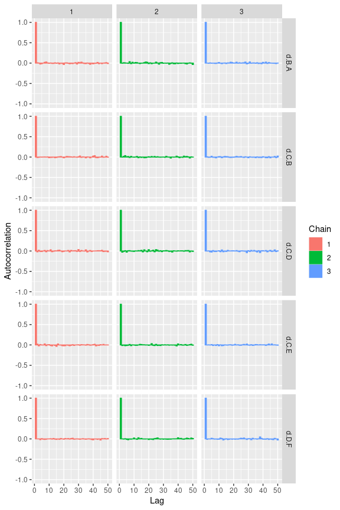

```r
ggs_autocorrelation(ggs(model$samples))
```

**Figure** Running means

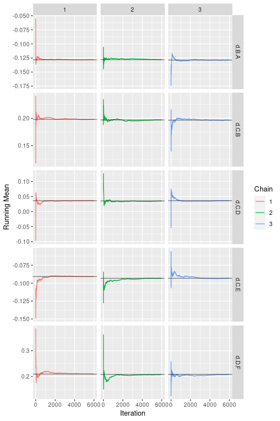

```r
ggs_running(ggs(model$samples))
```

# Produce outputs of interest

## Posterior summaries (log-scale)

The contrasts in this model are log-hazard ratios (which correspond to differences in log-hazard rates).

Unfortunately, `gemtc` does not provide an estimate of the effective sample size (`n.eff`). Instead, a time-series SE is given. As a rule of thumb, the length of the MCMC is sufficient if the time-series SE is smaller than 2%(-5%) of the posterior SD.

```r
summary(model)
```

```
##
## Results on the Mean Difference scale
##
## Iterations = 1:6000
## Thinning interval = 1
## Number of chains = 3
## Sample size per chain = 6000
##
## 1. Empirical mean and standard deviation for each variable,
##    plus standard error of the mean:
##
##           Mean      SD  Naive SE Time-series SE
## d.B.A -0.12835 0.05539 0.0004129      0.0004129
## d.C.B  0.19726 0.08320 0.0006201      0.0006313
## d.C.D  0.03578 0.12182 0.0009080      0.0008890
## d.C.E -0.09242 0.06593 0.0004914      0.0004910
## d.D.F  0.20852 0.19508 0.0014540      0.0014541
##
## 2. Quantiles for each variable:
##
##           2.5%      25%      50%      75%    97.5%
## d.B.A -0.23636 -0.16594 -0.12837 -0.09106 -0.01975
## d.C.B  0.03411  0.14194  0.19794  0.25263  0.36011
## d.C.D -0.20209 -0.04794  0.03582  0.11856  0.27699
## d.C.E -0.22187 -0.13704 -0.09198 -0.04728  0.03591
## d.D.F -0.17147  0.07815  0.20894  0.33972  0.59366
##
## -- Model fit (residual deviance):
##
##      Dbar        pD       DIC
##  5.481882  4.980620 10.462501
##
## 7 data points, ratio 0.7831, I^2 = 0%
```

To judge overall model fit, the residual deviance should be compared to the number of independent data points (which can be done via a small utility function in `gemtcPlus`).

```r
get_mtc_sum(model)
```

```
##     DIC   pD resDev dataPoints
## 1 10.46 4.98   5.48          7
```

## Hazard ratio estimates

Assume new treatment is “A” and is to be compared vs all other treatments.

**Table** Hazard ratios A vs other treatments

```r
HR <- get_mtc_newVsAll(model, new.lab = "A", transform = "exp", digits = 2)
HR
```

```
##   Comparator  Med CIlo CIup
## 1          B 0.88 0.79 0.98
## 2          C 1.07 0.88 1.30
## 3          D 1.03 0.76 1.41
## 4          E 1.17 0.93 1.48
## 5          F 0.84 0.51 1.37
```

**Table** Probability A better than other treatments (better meaning smaller HR)

```r
get_mtc_probBetter(model, new.lab = "A", smaller.is.better = TRUE, sort.by = "effect")
```

```
##   New Comparator probNewBetter
## 1   A          B         0.989
## 5   A          F         0.756
## 3   A          D         0.415
## 2   A          C         0.244
## 4   A          E         0.090
```

**Figure** Forest plot A vs other treatments

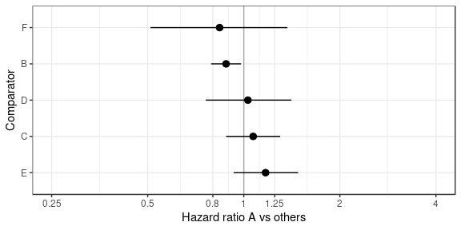

```r
plot_mtc_forest(x = HR, lab = "Hazard ratio A vs others", sort.by = "effect")
```

**Table** Cross-tabulation of HRs

```r
ctab <- round(exp(relative.effect.table(model)), 2)
pander::pandoc.table(as.data.frame(ctab), split.tables = Inf)
```

|  | A | B | C | D | E | F |
| --- | --- | --- | --- | --- | --- | --- |
| **A** | A | 1.14 (1.02, 1.27) | 0.93 (0.77, 1.14) | 0.97 (0.71, 1.32) | 0.85 (0.67, 1.08) | 1.19 (0.73, 1.94) |
| **B** | 0.88 (0.79, 0.98) | B | 0.82 (0.7, 0.97) | 0.85 (0.64, 1.14) | 0.75 (0.61, 0.92) | 1.05 (0.65, 1.68) |
| **C** | 1.07 (0.88, 1.3) | 1.22 (1.03, 1.43) | C | 1.04 (0.82, 1.32) | 0.91 (0.8, 1.04) | 1.28 (0.82, 2.01) |
| **D** | 1.03 (0.76, 1.41) | 1.18 (0.88, 1.57) | 0.96 (0.76, 1.22) | D | 0.88 (0.69, 1.13) | 1.23 (0.84, 1.81) |
| **E** | 1.17 (0.93, 1.48) | 1.34 (1.08, 1.64) | 1.1 (0.96, 1.25) | 1.14 (0.89, 1.45) | E | 1.4 (0.89, 2.19) |
| **F** | 0.84 (0.51, 1.37) | 0.95 (0.59, 1.54) | 0.78 (0.5, 1.22) | 0.81 (0.55, 1.19) | 0.71 (0.46, 1.12) | F |

## Treatment rankings

```r
rk  <- rank.probability(model, preferredDirection = -1)
mrk <- reshape2::melt(rk[,], varnames = c("Treatment", "Rank"), value.name = "Probability")

fig <- ggplot(data = mrk) +
  geom_line(aes(Rank, Probability, color = Treatment, linetype = Treatment), size = 1.5) +
  theme_bw()
```

**Figure** Rankogram

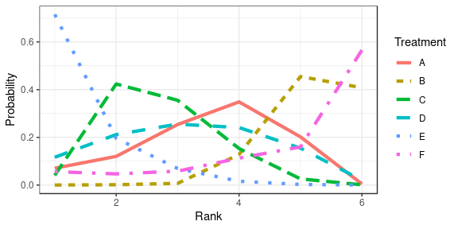

```r
plot(fig)
```

**Table** Rank probabilities

```r
colnames(rk) <- paste("Rank", 1:ncol(rk))
rk
```

```
## Rank probability; preferred direction = -1
##         Rank 1      Rank 2      Rank 3     Rank 4      Rank 5      Rank 6
## A 7.061111e-02 0.120333333 0.253888889 0.34872222 0.201944444 0.004500000
## B 5.555556e-05 0.001333333 0.007222222 0.12822222 0.455000000 0.408166667
## C 4.072222e-02 0.423777778 0.355500000 0.15322222 0.025722222 0.001055556
## D 1.165000e-01 0.211666667 0.255555556 0.24111111 0.154833333 0.020333333
## E 7.158333e-01 0.196111111 0.069555556 0.01583333 0.002666667 0.000000000
## F 5.627778e-02 0.046777778 0.058277778 0.11288889 0.159833333 0.565944444
```

# Extract model code (e.g. for Appendix)

```r
cat(model$model$code)
```

```
## model {
##  # Likelihood for arm-based data
##  ## OMITTED
##  # Likelihood for contrast-based data (univariate for 2-arm trials)
##  for(i in studies.r2) {
##      for (k in 2:na[i]) {
##          mest[i, k] <- delta[i, k]
##      }
##      m[i, 2] ~ dnorm(mest[i, 2], prec[i, 2])
##      prec[i, 2] <- 1 / (e[i, 2] * e[i, 2])
##
##      dev[i, 1] <- pow(m[i, 2] - mest[i, 2], 2) * prec[i, 2]
##  }
##  # Likelihood for contrast-based data (multivariate for multi-arm trials)
##  ## OMITTED
##
##  # Fixed effect model
##  for (i in studies) {
##      delta[i, 1] <- 0
##      for (k in 2:na[i]) {
##          delta[i, k] <- d[t[i, 1], t[i, k]]
##      }
##  }
##
##  # Relative effect matrix
##  d[1, 1] <- 0
##  d[1, 2] <- -d.B.A
##  d[1, 3] <- -d.B.A + -d.C.B
##  d[1, 4] <- -d.B.A + -d.C.B + d.C.D
##  d[1, 5] <- -d.B.A + -d.C.B + d.C.E
##  d[1, 6] <- -d.B.A + -d.C.B + d.C.D + d.D.F
##  for (i in 2:nt) {
##      for (j in 1:nt) {
##          d[i, j] <- d[1, j] - d[1, i]
##      }
##  }
##
##  prior.prec <- pow(15 * om.scale, -2)
##
##  # Study baseline priors
##  ## OMITTED
##
##  # Effect parameter priors
##  d.B.A ~ dnorm(0, prior.prec)
##  d.C.B ~ dnorm(0, prior.prec)
##  d.C.D ~ dnorm(0, prior.prec)
##  d.C.E ~ dnorm(0, prior.prec)
##  d.D.F ~ dnorm(0, prior.prec)
##
## }
```

# Session info

BEE repository: /home/bceuser/benneti1/gemtcPlus/vignettes

```r
date()
```

```
## [1] "Fri Jun 19 15:47:59 2020"
```